# Improvement Areas for Edify

# Feelings

### What were ninjas feeling at the end of investigate session?

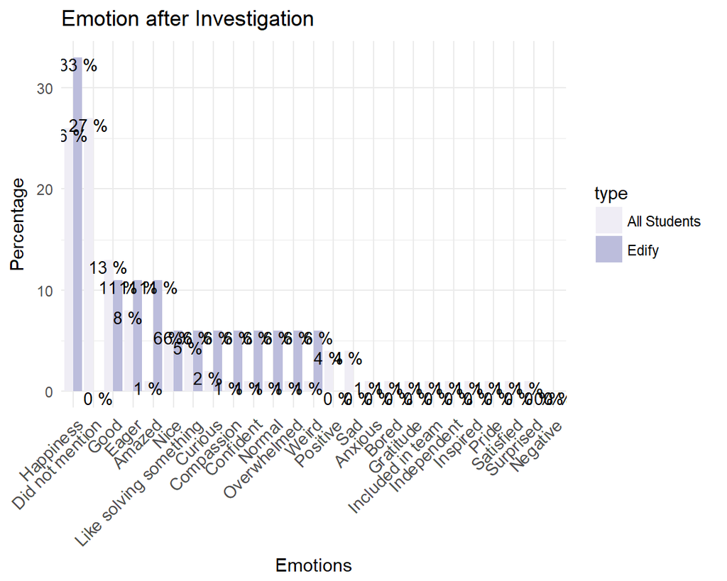

# Problems & Solutions

### Problems and solutions found by ninjas across all schools

This graph consists of 3 circles. The inner circle denotes themes of issues found by ninjas. The middle circle shows whether the ninja mentioned a solution of type report, solution or campaign. The outer circle denotes themes of solutions.

[interactive chart not shown]

### Problems and solutions found by ninjas of Edify School

This graph consists of 3 circles. The inner circle denotes themes of issues found by ninjas. The middle circle shows whether the ninja mentioned a solution of type report, solution or campaign. The outer circle denotes themes of solutions.

[interactive chart not shown]

# Changes in Audit

### If ninjas had to create the audit document by themselves, how would they improve it?

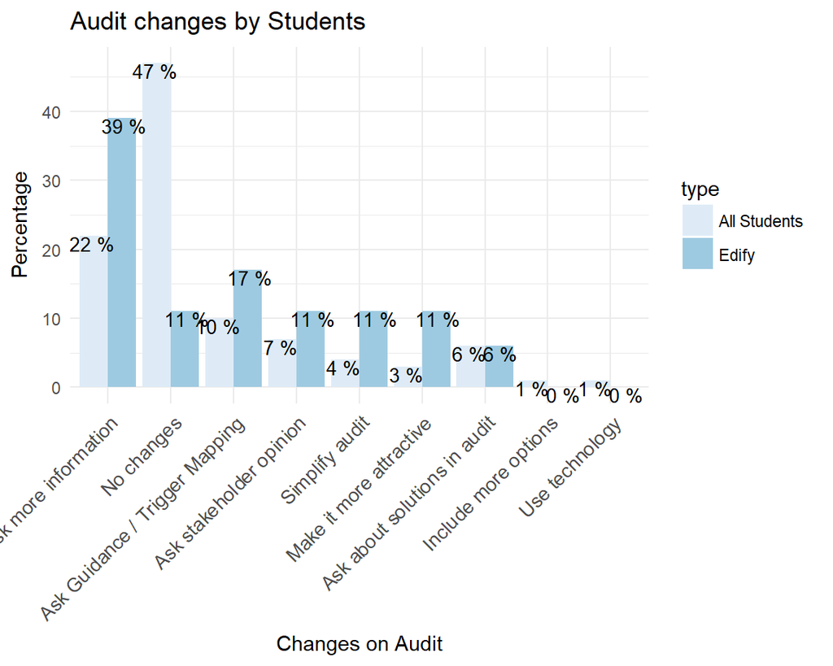

# Audit Feedback

### Did ninjas find doing the audit/investigation useful?

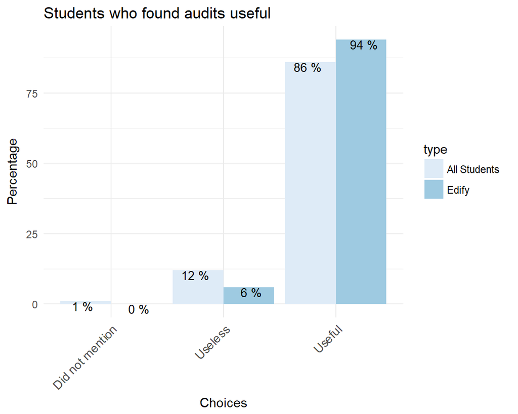

### How easy did ninjas find the audit?

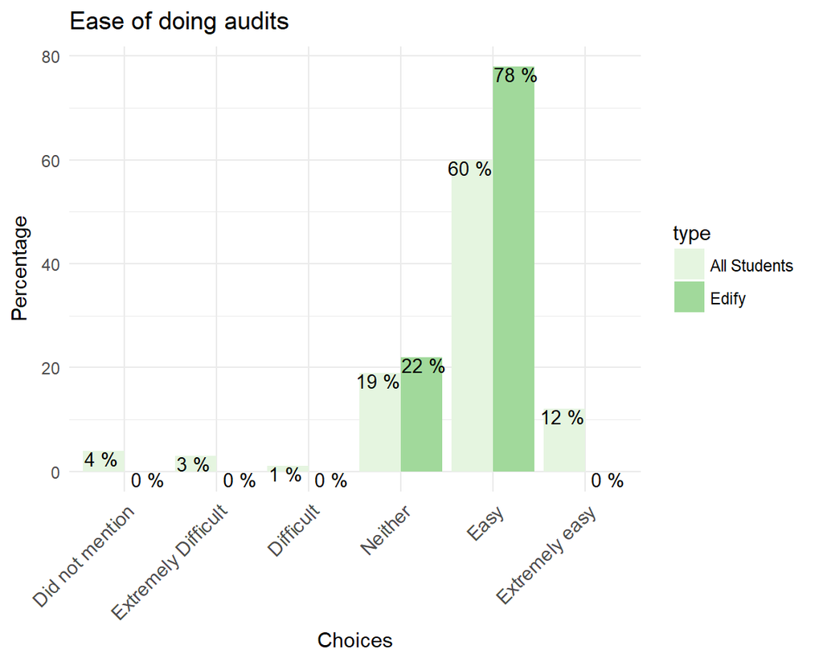

# Opinions on Stakeholders

### Did ninjas speak to people who would be most affected by this problem?

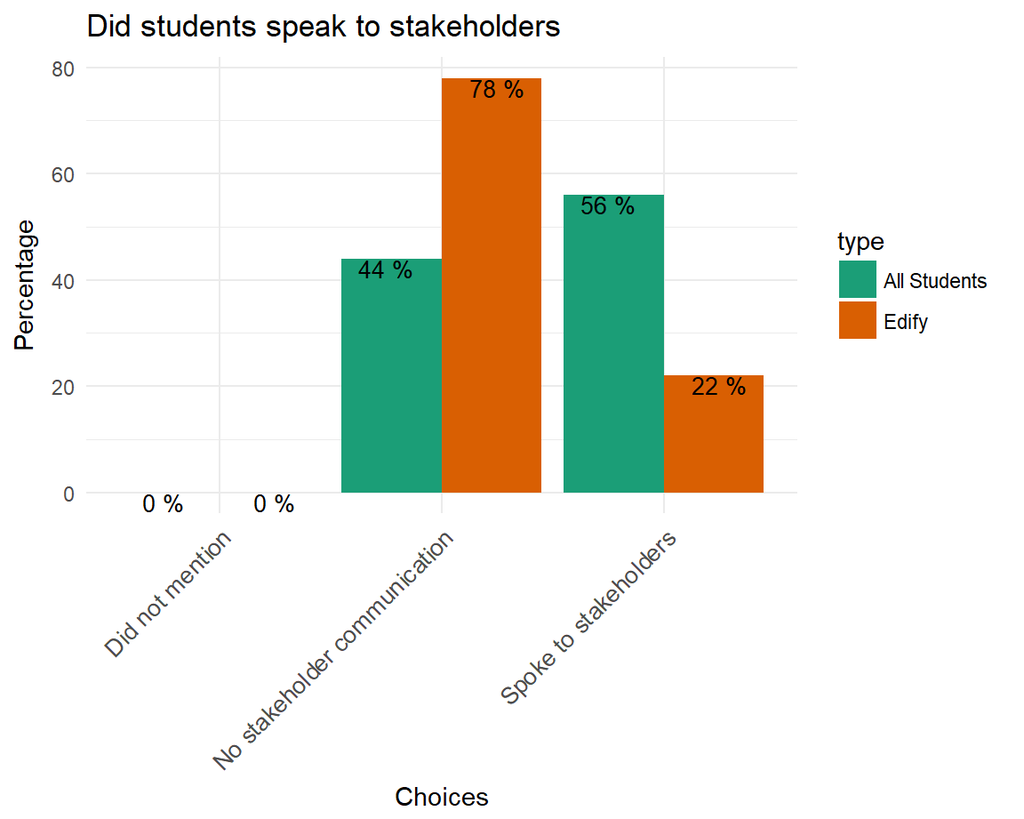

### How confident are ninjas that people facing the issues would accept the solution they provided?

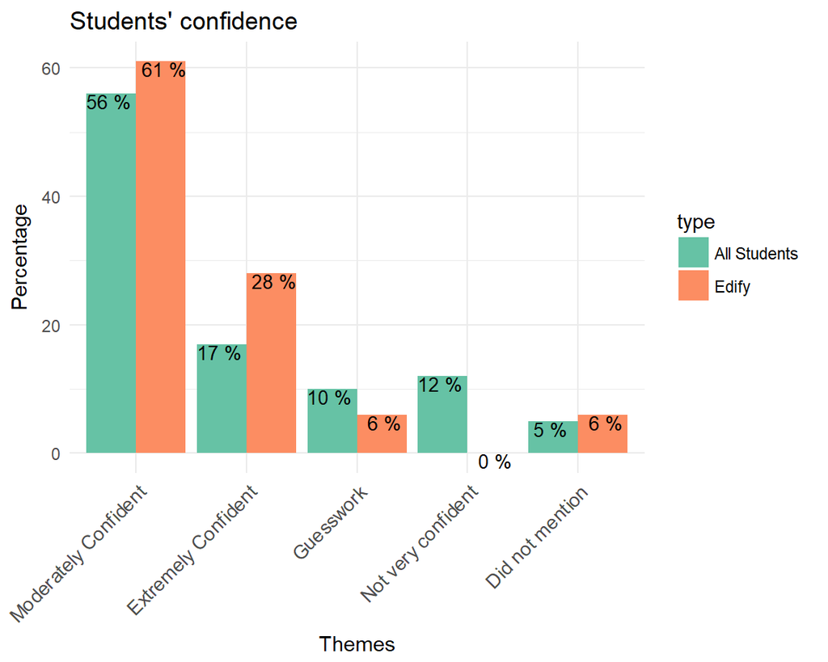